# Regression Discontinuity

## 1.3 Plotting Data

Plot each generated dataset. By looking at the plots, it becomes clear that the slope is steep on the control side. It is worth noting that in the original function shape, the steep slope belongs to the treatment side. However, in discrete RD, estimating the control side poses a bigger challenge, hence the function shape is reversed in this case.

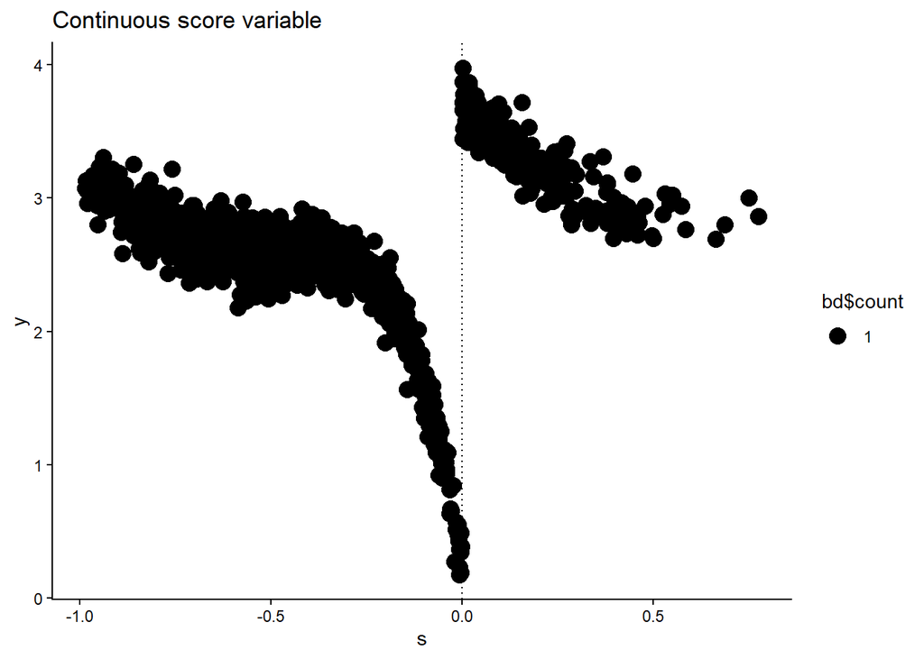

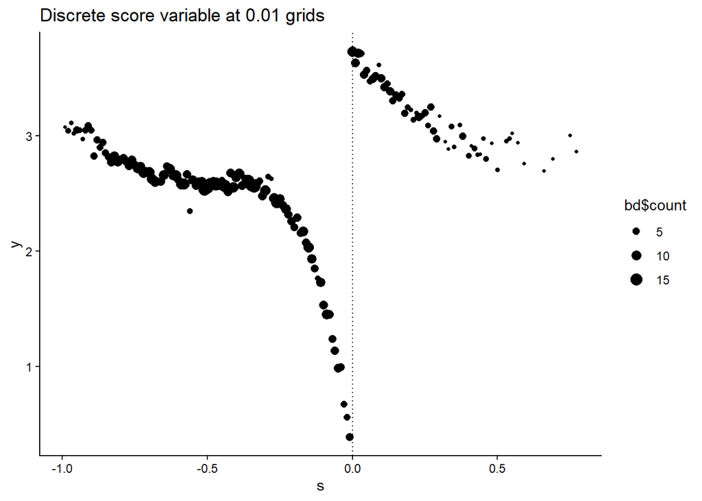

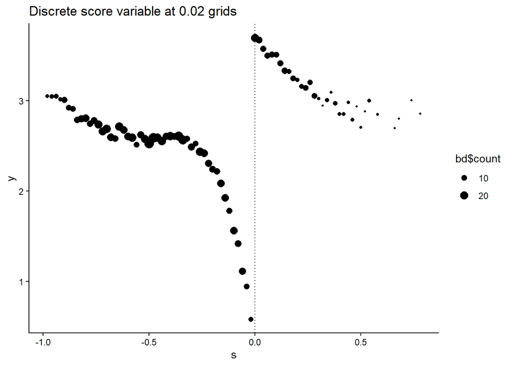

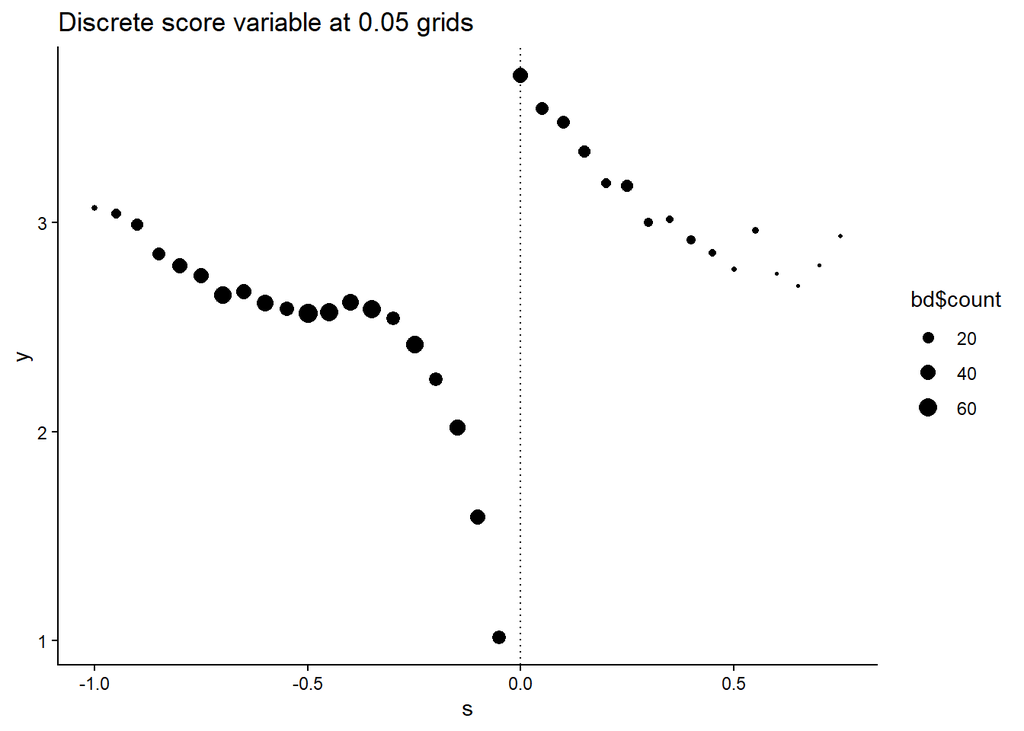

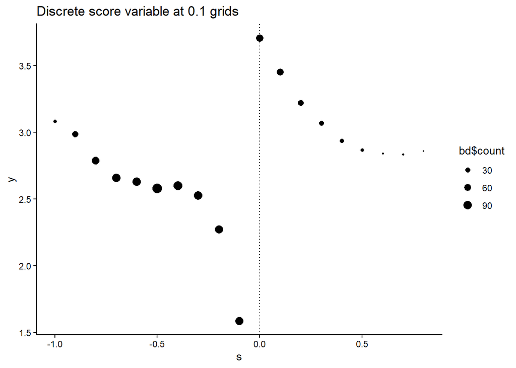

```r
list_plots <-
  purrr::map(
    .x = dgp_all,
    .f = call_plot_data
  )

counter <- 0
for (
  plot in list_plots
) {
  counter <- counter + 1
  plot_to_display <-
    plot +
    ggtitle(
      list_specifications[counter]
    )
  print(plot_to_display)
}
```

As we approach situations where observations are clearly discrete, it becomes evident that estimating the endpoint on the control side becomes challenging.